# ReCell

#### Question1: What does the distribution of used phone prices look like?

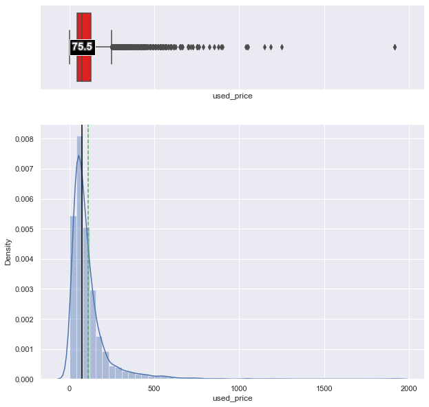

```python
 box_and_histogram(data['used_price'])
```

**Question 1: Answer**

- Right-skewed distibution, with some outliers on the right.

#### Question2 : What percentage of the used phone market is dominated by Android devices?

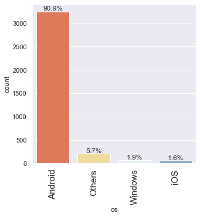

```python
labeled_barplot(data, 'os', True)
```

**Question 2: Answer**

- Almost 91% of the used phone market is dominated by Android devices.

#### Question3 : How does the amount of RAM vary with the brand?

#### Ram Vs Brand

```python
# take only ram columns where is not na
data_ram = data[data['ram'].notna()]
```

```python
data_ram.shape
```

```
(3561, 15)
```

```python
data_ram.groupby('brand_name')['ram'].mean().reset_index().sort_values('ram',ascending = False)
```

|  | brand_name | ram |
| --- | --- | --- |
| 22 | OnePlus | 6.363636 |
| 23 | Oppo | 4.961240 |
| 30 | Vivo | 4.756410 |
| 11 | Huawei | 4.641326 |
| 10 | Honor | 4.593220 |
| 32 | Xiaomi | 4.567164 |
| 8 | Google | 4.533333 |
| 17 | Meizu | 4.451613 |
| 26 | Realme | 4.195122 |
| 27 | Samsung | 4.159341 |
| 28 | Sony | 4.068182 |
| 3 | Asus | 4.047619 |
| 33 | ZTE | 4.023050 |
| 9 | HTC | 4.000000 |
| 25 | Panasonic | 4.000000 |
| 2 | Apple | 4.000000 |
| 31 | XOLO | 4.000000 |
| 19 | Microsoft | 4.000000 |
| 6 | Coolpad | 3.954545 |
| 20 | Motorola | 3.945455 |
| 7 | Gionee | 3.933036 |
| 0 | Acer | 3.901961 |
| 14 | LG | 3.893868 |
| 16 | Lenovo | 3.886628 |
| 4 | BlackBerry | 3.829545 |
| 24 | Others | 3.751041 |
| 18 | Micromax | 3.750000 |
| 29 | Spice | 3.750000 |
| 21 | Nokia | 3.601351 |
| 1 | Alcatel | 3.426000 |
| 13 | Karbonn | 3.375000 |
| 15 | Lava | 3.277778 |
| 12 | Infinix | 2.600000 |
| 5 | Celkon | 1.466216 |

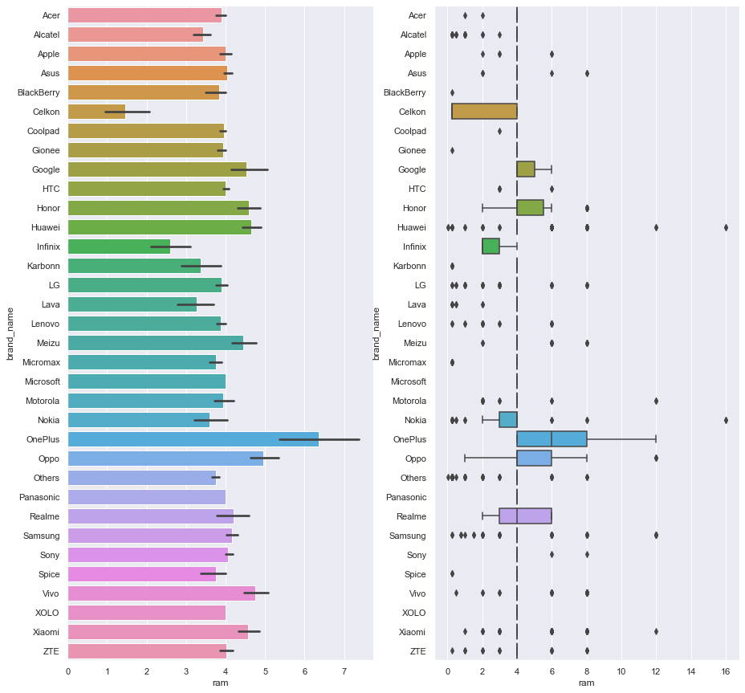

```python
plt.rcParams["figure.figsize"] = (15,15)

plt.subplot(1, 2, 1)

sns.barplot(data=data_ram, x="ram", y="brand_name")
#plt.xticks(rotation=45)

plt.subplot(1, 2, 2)
sns.boxplot(data=data_ram, x="ram", y="brand_name")
#plt.xticks(rotation=90)

plt.show()
```

**Question 3: Answers**

- Oneplus, Oppo and Vivo offer the max RAM

### Question 4: How does the weight vary for phones offering large batteries (more than 4500 mAh)?

#### Phones with battery > 4500 mAh

```python
phones_gt_4500mAh = data[data['battery'] > 4500]
```

```python
phones_gt_4500mAh.shape
```

```
(346, 15)
```

```python
phones_gt_4500mAh.groupby('brand_name')['battery'].count()\
.reset_index().sort_values('battery',ascending = False)
```

|  | brand_name | battery |
| --- | --- | --- |
| 27 | Samsung | 52 |
| 24 | Others | 41 |
| 11 | Huawei | 37 |
| 32 | Xiaomi | 31 |
| 16 | Lenovo | 29 |
| 3 | Asus | 22 |
| 2 | Apple | 19 |
| 10 | Honor | 14 |
| 20 | Motorola | 14 |
| 30 | Vivo | 13 |
| 14 | LG | 12 |
| 26 | Realme | 12 |
| 33 | ZTE | 10 |
| 7 | Gionee | 10 |
| 0 | Acer | 7 |
| 28 | Sony | 6 |
| 12 | Infinix | 6 |
| 23 | Oppo | 4 |
| 9 | HTC | 1 |
| 1 | Alcatel | 1 |
| 18 | Micromax | 1 |
| 21 | Nokia | 1 |
| 25 | Panasonic | 1 |
| 8 | Google | 1 |
| 29 | Spice | 1 |
| 4 | BlackBerry | 0 |
| 31 | XOLO | 0 |
| 5 | Celkon | 0 |
| 15 | Lava | 0 |
| 6 | Coolpad | 0 |
| 13 | Karbonn | 0 |
| 22 | OnePlus | 0 |
| 19 | Microsoft | 0 |
| 17 | Meizu | 0 |

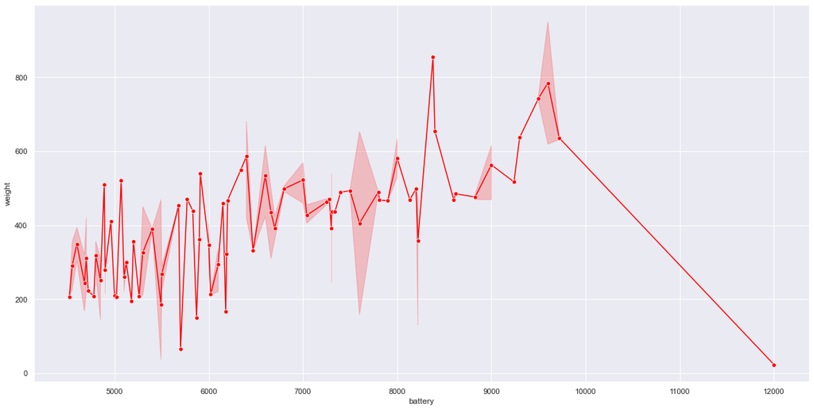

```python
plt.rcParams["figure.figsize"] = (20,10)
sns.lineplot(x=phones_gt_4500mAh['battery'],y=phones_gt_4500mAh['weight'],ci=95, marker='o', color ="red");
```

**Question 4 : Answers**

- There appears to be an outlier for the battery with 12000 mAh , the weight of this is unsually less
- With the increase in battery power the weight of the battery increases

### Question 5: How many phones are available across different brands with a screen size larger than 6 inches?

#### screen size larger than 6 inches

```python
phones_gt_6inch = data[data['screen_size'] > 6*2.54]
```

```python
  data[data['screen_size'] > 6*2.54].groupby(['brand_name'])['screen_size']\
    .count().reset_index().sort_values('screen_size',ascending=False)
```

|  | brand_name | screen_size |
| --- | --- | --- |
| 11 | Huawei | 159 |
| 27 | Samsung | 128 |
| 24 | Others | 116 |
| 10 | Honor | 87 |
| 30 | Vivo | 86 |
| 32 | Xiaomi | 85 |
| 16 | Lenovo | 72 |
| 23 | Oppo | 70 |
| 14 | LG | 68 |
| 3 | Asus | 44 |
| 20 | Motorola | 44 |
| 26 | Realme | 40 |
| 21 | Nokia | 28 |
| 1 | Alcatel | 28 |
| 17 | Meizu | 25 |
| 2 | Apple | 24 |
| 33 | ZTE | 22 |
| 0 | Acer | 19 |
| 22 | OnePlus | 16 |
| 28 | Sony | 14 |
| 18 | Micromax | 11 |
| 12 | Infinix | 10 |
| 9 | HTC | 8 |
| 7 | Gionee | 7 |
| 31 | XOLO | 4 |
| 8 | Google | 4 |
| 6 | Coolpad | 3 |
| 5 | Celkon | 2 |
| 4 | BlackBerry | 2 |
| 15 | Lava | 2 |
| 29 | Spice | 2 |
| 13 | Karbonn | 2 |
| 25 | Panasonic | 2 |
| 19 | Microsoft | 1 |

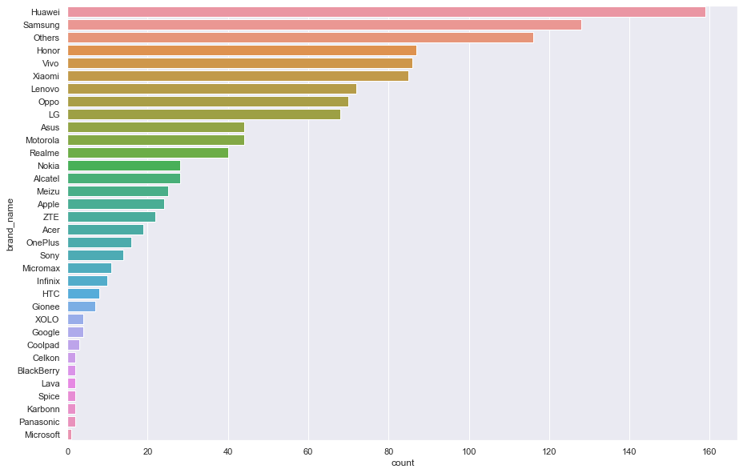

```python
plt.rcParams["figure.figsize"] = (15,10)
sns.countplot(y=phones_gt_6inch['brand_name'], order = phones_gt_6inch['brand_name']\
              .value_counts().index);
```

**Question 5- Answers**

- Huawei, Samsung offer the most number of phones with screen size greater than 6 inches

### Question 6: What is the distribution of budget phones offering greater than 8MP selfie cameras across brands?

#### Distribution of budget phones offering greater than 8MP selfie cameras across brands

#### Let's have 100 Euros as the cut off for budget phones

##### Create bin for the used price

```python
data_with_bins =data.copy()
# binned_used_price

# add custom labels
data_with_bins['used_price_bin'] = pd.cut(
    data_with_bins['used_price'], [-np.inf, 50, 100, 200, 250, 300, 400, 500, 600, 700, 1000, 1500, 2000, np.inf],\
    labels = ["Under_50", "50-100", "100-200", "200-250", "250-300", "300-400", "400-500", "500-600", "600-700",\
              "700-1000","1000-1500", "1500-2000" ,"Above_2000"])

data_with_bins['used_price_bin'].value_counts(dropna=False)
```

```
50-100        1259
Under_50      1028
100-200        892
200-250        110
250-300         84
300-400         79
400-500         52
500-600         33
700-1000        14
600-700         12
1000-1500        6
1500-2000        2
Above_2000       0
Name: used_price_bin, dtype: int64
```

#### Let's bin the new_price also to get a view of the distribution

```python
# binned_new_price

# add custom labels
data_with_bins['new_price_bin'] = pd.cut(
    data_with_bins['new_price'], [-np.inf, 50, 100, 200, 250, 300, 400, 500, 600, 700, 1000, 1500, 2000, np.inf],\
    labels = ["Under_50", "50-100", "100-200", "200-250", "250-300", "300-400", "400-500", "500-600", "600-700",\
              "700-1000","1000-1500", "1500-2000" ,"Above_2000"])

data_with_bins['new_price_bin'].value_counts(dropna=False)
```

```
100-200       1291
50-100         485
200-250        458
250-300        387
300-400        380
400-500        196
Under_50       128
500-600         81
700-1000        74
600-700         60
1000-1500       22
1500-2000        5
Above_2000       4
Name: new_price_bin, dtype: int64
```

#### Let's have 100 Euros as the cut off for budget phones

- Let's divide the phones into 4 broad categories
- Budget, Medium, High, Advanced

```python
# used_price_category
# add custom labels
data_with_bins['used_price_category'] = pd.cut(
    data_with_bins['used_price'], [-np.inf, 100, 300, 1000, np.inf],\
    labels = ["Budget_phones", "Medium_level","Hight_End", "Advanced"])

data_with_bins['used_price_category'].value_counts(dropna=False)
```

```
Budget_phones    2287
Medium_level     1086
Hight_End         190
Advanced            8
Name: used_price_category, dtype: int64
```

#### Budget_phones with selfie camers greater than 8 Mp

```python
budget_phones_8mp = data_with_bins[ (data_with_bins['used_price_category'] == 'Budget_phones')\
                         & ( data_with_bins['selfie_camera_mp'] > 8)]
budget_phones_8mp.shape
```

```
(106, 18)
```

```python
budget_phones_8mp.brand_name.value_counts()
```

```
Xiaomi        11
Realme         9
Vivo           8
Sony           7
Samsung        7
Oppo           7
Honor          7
Huawei         7
ZTE            6
Lenovo         6
Others         5
Infinix        4
Meizu          4
HTC            4
Asus           3
Motorola       3
LG             3
Nokia          2
Acer           1
Gionee         1
Panasonic      1
Celkon         0
Apple          0
XOLO           0
Spice          0
BlackBerry     0
Karbonn        0
Coolpad        0
OnePlus        0
Microsoft      0
Micromax       0
Alcatel        0
Lava           0
Google         0
Name: brand_name, dtype: int64
```

**Question6 : Answers**

- Xiaomi,Realme and Vivo offer many models with selfie camera with more than 8Mp on budget price
- Sony, Samsung, Oppo, Honor and Huawei also good number of models with selfie camera more than 8Mp on budget

#### log transformation of price

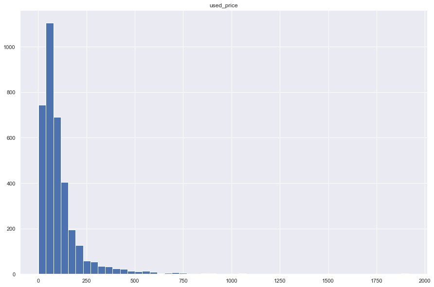

```
0
```

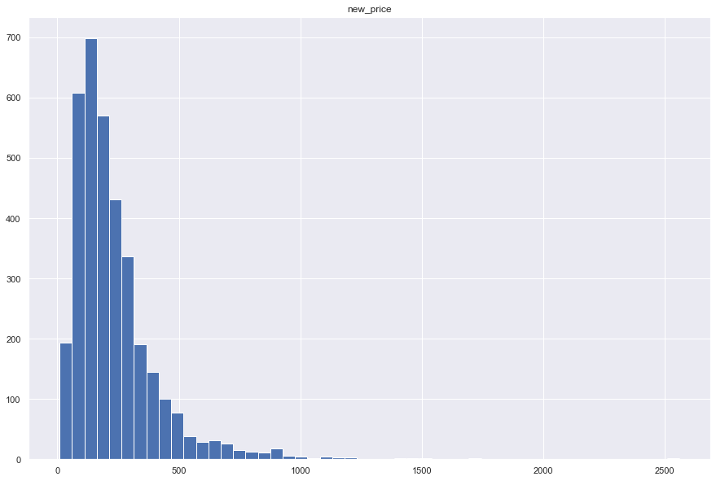

```
0
```

```python
cols_to_log = ['used_price', 'new_price']
for colname in cols_to_log:
    plt.hist(data[colname], bins=50)
    plt.title(colname)
    plt.show()
    print(np.sum(data[colname] <= 0))
```

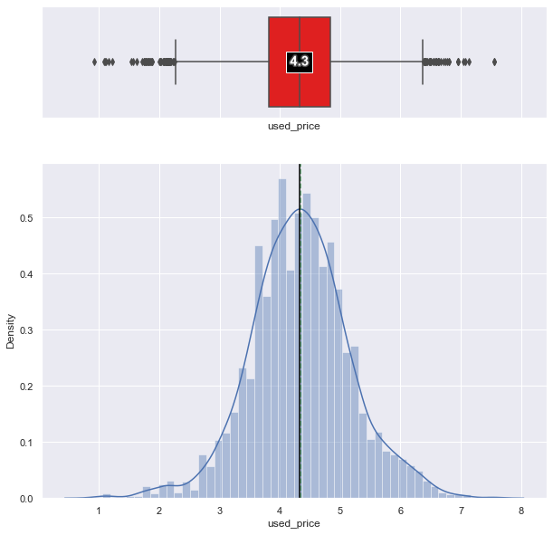

```python
box_and_histogram(np.log(data['used_price']))
```

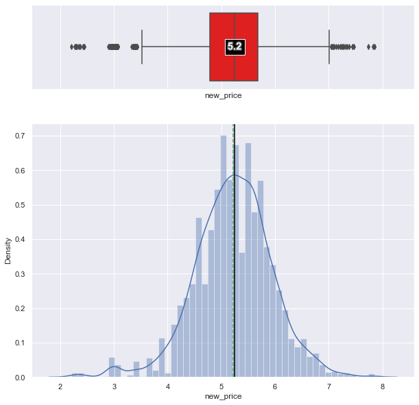

```python
box_and_histogram(np.log(data['new_price']))
```

**Observation**

- The used price on applying log transformation , converts to almost normal distribution, with some outliers

## Data Preprocessing for liner model building

- We want to predict the used_price.
- Before we proceed to build a model, we'll have to encode categorical features.
- We'll split the data into train and test to be able to evaluate the model that we build on the train data.
- We will build a Linear Regression model using the train data and then check it's performance.

```python
data.info()
```

```
<class 'pandas.core.frame.DataFrame'>
RangeIndex: 3571 entries, 0 to 3570
Data columns (total 15 columns):
 #   Column            Non-Null Count  Dtype
---  ------            --------------  -----
 0   brand_name        3571 non-null   category
 1   os                3571 non-null   category
 2   screen_size       3571 non-null   float64
 3   4g                3571 non-null   category
 4   5g                3571 non-null   category
 5   main_camera_mp    3391 non-null   float64
 6   selfie_camera_mp  3569 non-null   float64
 7   int_memory        3561 non-null   float64
 8   ram               3561 non-null   float64
 9   battery           3565 non-null   float64
 10  weight            3564 non-null   float64
 11  release_year      3571 non-null   int64
 12  days_used         3571 non-null   int64
 13  new_price         3571 non-null   float64
 14  used_price        3571 non-null   float64
dtypes: category(4), float64(9), int64(2)
memory usage: 322.7 KB
```

```python
data.select_dtypes(exclude ='category').columns
```

```
Index(['screen_size', 'main_camera_mp', 'selfie_camera_mp', 'int_memory',
       'ram', 'battery', 'weight', 'release_year', 'days_used', 'new_price',
       'used_price'],
      dtype='object')
```

[figure not shown]

```python
# let's plot the boxplots of all columns to check for outliers
plt.figure(figsize=(20, 30))

for i, variable in enumerate(numeric_columns):
    plt.subplot(5, 4, i + 1)
    plt.boxplot(data[variable], whis=1.5)
    plt.tight_layout()
    plt.title(variable)

plt.show()
```

### Outlier Treatment

- Let's treat outliers in the data by flooring and capping.

```python
def treat_outliers(df, col):
    """
    treats outliers in a variable
    col: str, name of the numerical variable
    df: dataframe
    col: name of the column
    """
    Q1 = df[col].quantile(0.25)  # 25th quantile
    Q3 = df[col].quantile(0.75)  # 75th quantile
    IQR = Q3 - Q1
    Lower_Whisker = Q1 - 1.5 * IQR
    Upper_Whisker = Q3 + 1.5 * IQR

    # all the values smaller than Lower_Whisker will be assigned the value of Lower_Whisker
    # all the values greater than Upper_Whisker will be assigned the value of Upper_Whisker
    df[col] = np.clip(df[col], Lower_Whisker, Upper_Whisker)

    return df


def treat_outliers_all(df, col_list):
    """
    treat outlier in all numerical variables
    col_list: list of numerical variables
    df: data frame
    """
    for c in col_list:
        df = treat_outliers(df, c)

    return df
```

```python
numerical_col = data.select_dtypes(include=np.number).columns.tolist()
data_out_treated = treat_outliers_all(data, numerical_col)
```

[figure not shown]

```python
# let's look at the boxplots to see if the outliers have been treated or not
plt.figure(figsize=(20, 30))

for i, variable in enumerate(numeric_columns):
    plt.subplot(5, 4, i + 1)
    plt.boxplot(data_out_treated[variable], whis=1.5)
    plt.tight_layout()
    plt.title(variable)

plt.show()
```

### Drop drop all rows that have any NaN values

```python
data_lin = data_out_treated.dropna()
data_sm_model = data_out_treated.dropna()
```

```python
data_lin.shape
```

```
(3368, 15)
```

#### Add log tansformed data for used_price and new_price

```python
data_lin['used_price_log'] = np.log(data_lin['used_price'])
data_lin['new_price_log'] = np.log(data_lin['new_price'])
```

#### Let's add dummy columns for category columns

```python
brand_name_dum = pd.get_dummies(data_lin['brand_name'],drop_first =True)
brand_name_dum_all = pd.get_dummies(data_lin['brand_name'])
```

```python
os_dum = pd.get_dummies(data_lin['os'],drop_first =True)
```

```python
Four_G = pd.get_dummies(data_lin['4g'],drop_first =True)
Four_G.rename(columns={"yes": "4G_dum"},inplace = True)
```

```python
Five_G = pd.get_dummies(data_lin['5g'],drop_first =True)
Five_G.rename(columns={"yes": "5G_dum"},inplace = True)
```

### Linear model with sklearn learn

```python
data_lin =  pd.concat([data_lin,brand_name_dum, os_dum, Four_G, Five_G ],axis=1)
```

```python
data_lin.shape
```

```
(3368, 55)
```

```python
col_to_drop= ['brand_name', 'os', '4g', '5g']
log_nor_columns = ['used_price', 'new_price']
```

```python
data_lin.drop(col_to_drop, inplace=True, axis=1)
data_lin.drop(log_nor_columns, inplace=True, axis=1)
```

```python
data_lin
```

|  | screen_size | main_camera_mp | selfie_camera_mp | int_memory | ram | battery | weight | release_year | days_used | used_price_log | new_price_log | Alcatel | Apple | Asus | BlackBerry | Celkon | Coolpad | Gionee | Google | HTC | Honor | Huawei | Infinix | Karbonn | LG | Lava | Lenovo | Meizu | Micromax | … |
| --- | --- | --- | --- | --- | --- | --- | --- | --- | --- | --- | --- | --- | --- | --- | --- | --- | --- | --- | --- | --- | --- | --- | --- | --- | --- | --- | --- | --- | --- | --- |
| 0 | 22.225 | 13.0 | 5.0 | 64.0 | 4.0 | 3020.0 | 146.0 | 2020 | 127 | 4.465448 | 4.715100 | 0 | 0 | 0 | 0 | 0 | 0 | 0 | 0 | 0 | 1 | 0 | 0 | 0 | 0 | 0 | 0 | 0 | 0 | … |
| 1 | 22.225 | 13.0 | 16.0 | 128.0 | 4.0 | 4300.0 | 213.0 | 2020 | 325 | 5.084443 | 5.519018 | 0 | 0 | 0 | 0 | 0 | 0 | 0 | 0 | 0 | 1 | 0 | 0 | 0 | 0 | 0 | 0 | 0 | 0 | … |
| 2 | 22.225 | 13.0 | 8.0 | 128.0 | 4.0 | 4200.0 | 213.0 | 2020 | 162 | 5.510167 | 5.884631 | 0 | 0 | 0 | 0 | 0 | 0 | 0 | 0 | 0 | 1 | 0 | 0 | 0 | 0 | 0 | 0 | 0 | 0 | … |
| 3 | 22.225 | 13.0 | 8.0 | 64.0 | 4.0 | 6850.0 | 250.0 | 2020 | 345 | 5.194234 | 5.630961 | 0 | 0 | 0 | 0 | 0 | 0 | 0 | 0 | 0 | 1 | 0 | 0 | 0 | 0 | 0 | 0 | 0 | 0 | … |
| 4 | 15.720 | 13.0 | 8.0 | 64.0 | 4.0 | 5000.0 | 185.0 | 2020 | 293 | 4.642466 | 4.947837 | 0 | 0 | 0 | 0 | 0 | 0 | 0 | 0 | 0 | 1 | 0 | 0 | 0 | 0 | 0 | 0 | 0 | 0 | … |
| ... | ... | ... | ... | ... | ... | ... | ... | ... | ... | ... | ... | ... | ... | ... | ... | ... | ... | ... | ... | ... | ... | ... | ... | ... | ... | ... | ... | ... | ... | … |
| 3564 | 15.400 | 8.0 | 7.0 | 64.0 | 4.0 | 3110.0 | 194.0 | 2019 | 208 | 5.510167 | 6.287936 | 0 | 1 | 0 | 0 | 0 | 0 | 0 | 0 | 0 | 0 | 0 | 0 | 0 | 0 | 0 | 0 | 0 | 0 | … |
| 3567 | 15.240 | 13.0 | 8.0 | 128.0 | 4.0 | 4000.0 | 200.0 | 2018 | 541 | 5.510167 | 6.251546 | 0 | 0 | 1 | 0 | 0 | 0 | 0 | 0 | 0 | 0 | 0 | 0 | 0 | 0 | 0 | 0 | 0 | 0 | … |
| 3568 | 18.730 | 13.0 | 5.0 | 32.0 | 4.0 | 4000.0 | 165.0 | 2020 | 201 | 4.245777 | 4.528829 | 1 | 0 | 0 | 0 | 0 | 0 | 0 | 0 | 0 | 0 | 0 | 0 | 0 | 0 | 0 | 0 | 0 | 0 | … |
| 3569 | 18.730 | 13.0 | 5.0 | 32.0 | 4.0 | 4000.0 | 160.0 | 2020 | 149 | 4.331654 | 4.624139 | 1 | 0 | 0 | 0 | 0 | 0 | 0 | 0 | 0 | 0 | 0 | 0 | 0 | 0 | 0 | 0 | 0 | 0 | … |
| 3570 | 13.490 | 13.0 | 5.0 | 16.0 | 4.0 | 4000.0 | 168.0 | 2020 | 176 | 3.921577 | 4.280015 | 1 | 0 | 0 | 0 | 0 | 0 | 0 | 0 | 0 | 0 | 0 | 0 | 0 | 0 | 0 | 0 | 0 | 0 | … |

3368 rows × 49 columns

```python
data_lin.shape
```

```
(3368, 49)
```

```python
# defining X and y variables
X = data_lin.drop(["used_price_log"], axis=1)
y = data_lin["used_price_log"]
```

```python
X.shape
```

```
(3368, 48)
```

```python
# splitting the data in 70:30 ratio for train to test data

x_train, x_test, y_train, y_test = train_test_split(
    X, y, test_size=0.3, random_state=1
)
```

```python
print("Number of rows in train data =", x_train.shape[0])
print("Number of rows in test data =", x_test.shape[0])
```

```
Number of rows in train data = 2357
Number of rows in test data = 1011
```

```python
# fitting the model on the train data (70% of the whole data)

linearregression = LinearRegression()
linearregression.fit(x_train, y_train)
```

```
LinearRegression()
```

```python
coef_df = pd.DataFrame(
    np.append(linearregression.coef_, linearregression.intercept_),
    index=x_train.columns.tolist() + ["Intercept"],
    columns=["Coefficients"],
)

coef_df
```

|  | Coefficients |
| --- | --- |
| screen_size | 1.454855e-03 |
| main_camera_mp | 2.211955e-03 |
| selfie_camera_mp | 2.227340e-03 |
| int_memory | -3.516711e-04 |
| ram | -4.071604e-13 |
| battery | 1.860422e-06 |
| weight | 8.342298e-06 |
| release_year | -1.079343e-03 |
| days_used | -1.061436e-03 |
| new_price_log | 9.670384e-01 |
| Alcatel | -1.271639e-02 |
| Apple | -1.800151e-01 |
| Asus | 5.263316e-03 |
| BlackBerry | 4.138219e-02 |
| Celkon | 1.132326e-02 |
| Coolpad | 3.811245e-03 |
| Gionee | -1.546169e-02 |
| Google | -1.121045e-02 |
| HTC | -8.859524e-03 |
| Honor | 3.762155e-02 |
| Huawei | -5.764935e-04 |
| Infinix | 1.040834e-16 |
| Karbonn | -4.014385e-02 |
| LG | 6.989572e-04 |
| Lava | -1.114760e-02 |
| Lenovo | -1.733555e-02 |
| Meizu | -1.598522e-02 |
| Micromax | -1.478200e-02 |
| Microsoft | -2.067448e-02 |
| Motorola | 2.778232e-03 |
| Nokia | -7.174309e-03 |
| OnePlus | -7.299399e-03 |
| Oppo | -4.371301e-03 |
| Others | -1.142041e-03 |
| Panasonic | -1.769474e-02 |
| Realme | -7.675817e-02 |
| Samsung | 9.351905e-04 |
| Sony | -2.078877e-02 |
| Spice | -2.125741e-02 |
| Vivo | 1.035746e-03 |
| XOLO | -9.168902e-03 |
| Xiaomi | -1.513199e-02 |
| ZTE | -3.036003e-02 |
| Others | -1.667527e-02 |
| Windows | -7.774830e-03 |
| iOS | 1.960314e-01 |
| 4G_dum | -3.070761e-04 |
| 5G_dum | -1.681652e-01 |
| Intercept | 2.134044e+00 |

**Let's check the performance of the model using different metrics.**

- We will be using metric functions defined in sklearn for RMSE, MAE, and $R^2$.
- We will define a function to calculate MAPE and adjusted $R^2$.
  - The mean absolute percentage error (MAPE) measures the accuracy of predictions as a percentage, and can be calculated as the average absolute percent error for each predicted value minus actual values divided by actual values. It works best if there are no extreme values in the data and none of the actual values are 0.

```python
# function to compute adjusted R-squared
def adj_r2_score(predictors, targets, predictions):
    r2 = r2_score(targets, predictions)
    n = predictors.shape[0]
    k = predictors.shape[1]
    return 1 - ((1 - r2) * (n - 1) / (n - k - 1))


# function to compute MAPE
def mape_score(targets, predictions):
    return np.mean(np.abs(targets - predictions) / targets) * 100


# function to compute different metrics to check performance of a regression model
def model_performance_regression(model, predictors, target):
    """
    Function to compute different metrics to check regression model performance

    model: regressor
    predictors: independent variables
    target: dependent variable
    """

    # predicting using the independent variables
    pred = model.predict(predictors)

    r2 = r2_score(target, pred)  # to compute R-squared
    adjr2 = adj_r2_score(predictors, target, pred)  # to compute adjusted R-squared
    rmse = np.sqrt(mean_squared_error(target, pred))  # to compute RMSE
    mae = mean_absolute_error(target, pred)  # to compute MAE
    mape = mape_score(target, pred)  # to compute MAPE

    # creating a dataframe of metrics
    df_perf = pd.DataFrame(
        {
            "RMSE": rmse,
            "MAE": mae,
            "R-squared": r2,
            "Adj. R-squared": adjr2,
            "MAPE": mape,
        },
        index=[0],
    )

    return df_perf
```

```python
# checking model performance on train set (seen 70% data)
print("Training Performance\n")
linearregression_train_perf = model_performance_regression(
    linearregression, x_train, y_train
)
linearregression_train_perf
```

```
Training Performance
```

|  | RMSE | MAE | R-squared | Adj. R-squared | MAPE |
| --- | --- | --- | --- | --- | --- |
| 0 | 0.094446 | 0.07664 | 0.983244 | 0.982895 | 1.836847 |

```python
# checking model performance on test set (seen 30% data)
print("Test Performance\n")
linearregression_test_perf = model_performance_regression(
    linearregression, x_test, y_test
)
linearregression_test_perf
```

```
Test Performance
```

|  | RMSE | MAE | R-squared | Adj. R-squared | MAPE |
| --- | --- | --- | --- | --- | --- |
| 0 | 0.10114 | 0.080199 | 0.983241 | 0.982405 | 1.97683 |

**Observations**

## Linear Regression using statsmodels

- Let's build a linear regression model using statsmodels.

### Let's use non log transformed data

```python
data_with_dummies = pd.concat([data_sm_model,brand_name_dum, os_dum, Four_G, Five_G ],axis=1)
data_with_dummies
```

|  | brand_name | os | screen_size | 4g | 5g | main_camera_mp | selfie_camera_mp | int_memory | ram | battery | weight | release_year | days_used | new_price | used_price | Alcatel | Apple | Asus | BlackBerry | Celkon | Coolpad | Gionee | Google | HTC | Honor | Huawei | Infinix | Karbonn | LG | … |
| --- | --- | --- | --- | --- | --- | --- | --- | --- | --- | --- | --- | --- | --- | --- | --- | --- | --- | --- | --- | --- | --- | --- | --- | --- | --- | --- | --- | --- | --- | --- |
| 0 | Honor | Android | 22.225 | yes | no | 13.0 | 5.0 | 64.0 | 4.0 | 3020.0 | 146.0 | 2020 | 127 | 111.6200 | 86.9600 | 0 | 0 | 0 | 0 | 0 | 0 | 0 | 0 | 0 | 1 | 0 | 0 | 0 | 0 | … |
| 1 | Honor | Android | 22.225 | yes | yes | 13.0 | 16.0 | 128.0 | 4.0 | 4300.0 | 213.0 | 2020 | 325 | 249.3900 | 161.4900 | 0 | 0 | 0 | 0 | 0 | 0 | 0 | 0 | 0 | 1 | 0 | 0 | 0 | 0 | … |
| 2 | Honor | Android | 22.225 | yes | yes | 13.0 | 8.0 | 128.0 | 4.0 | 4200.0 | 213.0 | 2020 | 162 | 359.4700 | 247.1925 | 0 | 0 | 0 | 0 | 0 | 0 | 0 | 0 | 0 | 1 | 0 | 0 | 0 | 0 | … |
| 3 | Honor | Android | 22.225 | yes | yes | 13.0 | 8.0 | 64.0 | 4.0 | 6850.0 | 250.0 | 2020 | 345 | 278.9300 | 180.2300 | 0 | 0 | 0 | 0 | 0 | 0 | 0 | 0 | 0 | 1 | 0 | 0 | 0 | 0 | … |
| 4 | Honor | Android | 15.720 | yes | no | 13.0 | 8.0 | 64.0 | 4.0 | 5000.0 | 185.0 | 2020 | 293 | 140.8700 | 103.8000 | 0 | 0 | 0 | 0 | 0 | 0 | 0 | 0 | 0 | 1 | 0 | 0 | 0 | 0 | … |
| ... | ... | ... | ... | ... | ... | ... | ... | ... | ... | ... | ... | ... | ... | ... | ... | ... | ... | ... | ... | ... | ... | ... | ... | ... | ... | ... | ... | ... | ... | … |
| 3564 | Apple | iOS | 15.400 | yes | no | 8.0 | 7.0 | 64.0 | 4.0 | 3110.0 | 194.0 | 2019 | 208 | 538.0415 | 247.1925 | 0 | 1 | 0 | 0 | 0 | 0 | 0 | 0 | 0 | 0 | 0 | 0 | 0 | 0 | … |
| 3567 | Asus | Android | 15.240 | yes | no | 13.0 | 8.0 | 128.0 | 4.0 | 4000.0 | 200.0 | 2018 | 541 | 518.8145 | 247.1925 | 0 | 0 | 1 | 0 | 0 | 0 | 0 | 0 | 0 | 0 | 0 | 0 | 0 | 0 | … |
| 3568 | Alcatel | Android | 18.730 | yes | no | 13.0 | 5.0 | 32.0 | 4.0 | 4000.0 | 165.0 | 2020 | 201 | 92.6500 | 69.8100 | 1 | 0 | 0 | 0 | 0 | 0 | 0 | 0 | 0 | 0 | 0 | 0 | 0 | 0 | … |
| 3569 | Alcatel | Android | 18.730 | yes | no | 13.0 | 5.0 | 32.0 | 4.0 | 4000.0 | 160.0 | 2020 | 149 | 101.9150 | 76.0700 | 1 | 0 | 0 | 0 | 0 | 0 | 0 | 0 | 0 | 0 | 0 | 0 | 0 | 0 | … |
| 3570 | Alcatel | Android | 13.490 | yes | no | 13.0 | 5.0 | 16.0 | 4.0 | 4000.0 | 168.0 | 2020 | 176 | 72.2415 | 50.4800 | 1 | 0 | 0 | 0 | 0 | 0 | 0 | 0 | 0 | 0 | 0 | 0 | 0 | 0 | … |

3368 rows × 53 columns

```python
col_to_drop= ['brand_name', 'os', '4g', '5g']
```

```python
data_for_sm_model = data_with_dummies.drop(col_to_drop, axis=1)
data_for_sm_model.shape
```

```
(3368, 49)
```

```python
# defining X and y variables
X_sm = data_for_sm_model.drop(["used_price"], axis=1)
y_sm = data_for_sm_model["used_price"]
```

```python
# splitting the data in 70:30 ratio for train to test data

x_train_sm, x_test_sm, y_train_sm, y_test_sm = train_test_split(
    X_sm, y_sm, test_size=0.3, random_state=1
)
```

```python
x_train_sm.shape
```

```
(2357, 48)
```

```python
y_train_sm.shape
```

```
(2357,)
```

```python
## Linear Regression using statsmodels

x_train_sm_1 = sm.add_constant(x_train_sm)
# adding constant to the test data
x_test_sm_1 = sm.add_constant(x_test_sm)

olsmod0 = sm.OLS(y_train_sm, x_train_sm_1).fit()
print(olsmod0.summary())
```

```
                            OLS Regression Results
==============================================================================
Dep. Variable:             used_price   R-squared:                       0.956
Model:                            OLS   Adj. R-squared:                  0.955
Method:                 Least Squares   F-statistic:                     1095.
Date:                Sat, 21 Aug 2021   Prob (F-statistic):               0.00
Time:                        08:05:59   Log-Likelihood:                -9393.5
No. Observations:                2357   AIC:                         1.888e+04
Df Residuals:                    2310   BIC:                         1.915e+04
Df Model:                          46
Covariance Type:            nonrobust
====================================================================================
                       coef    std err          t      P>|t|      [0.025      0.975]
------------------------------------------------------------------------------------
screen_size          0.0963      0.122      0.790      0.430      -0.143       0.335
main_camera_mp      -0.2539      0.090     -2.828      0.005      -0.430      -0.078
selfie_camera_mp     0.6682      0.102      6.547      0.000       0.468       0.868
int_memory           0.0794      0.011      7.508      0.000       0.059       0.100
ram                141.3682    133.386      1.060      0.289    -120.201     402.937
battery             -0.0002      0.000     -0.382      0.703      -0.001       0.001
weight               0.0002      0.011      0.020      0.984      -0.022       0.023
release_year        -0.2496      0.265     -0.943      0.346      -0.769       0.269
days_used           -0.0854      0.002    -49.162      0.000      -0.089      -0.082
new_price            0.3876      0.003    116.292      0.000       0.381       0.394
Alcatel             -0.0741      2.548     -0.029      0.977      -5.071       4.922
Apple               10.5107      8.195      1.283      0.200      -5.560      26.581
Asus                -0.0240      2.578     -0.009      0.993      -5.079       5.031
BlackBerry           6.8812      4.839      1.422      0.155      -2.608      16.370
Celkon               0.1179      3.699      0.032      0.975      -7.137       7.372
Coolpad             -1.1529      4.159     -0.277      0.782      -9.309       7.003
Gionee              -5.0562      3.134     -1.613      0.107     -11.202       1.089
Google              17.2271      4.591      3.752      0.000       8.224      26.230
HTC                 -1.8055      2.653     -0.681      0.496      -7.007       3.396
Honor                4.5375      2.688      1.688      0.091      -0.733       9.808
Huawei               0.5333      2.400      0.222      0.824      -4.173       5.239
Infinix          -2.675e-13    2.2e-13     -1.213      0.225      -7e-13    1.65e-13
Karbonn             -0.4762      4.039     -0.118      0.906      -8.397       7.444
LG                   2.1942      2.436      0.901      0.368      -2.584       6.972
Lava                 0.1483      3.419      0.043      0.965      -6.557       6.854
Lenovo              -1.6698      2.446     -0.683      0.495      -6.467       3.127
```

[output cut: 18 more lines]

```
Windows              2.0088      2.622      0.766      0.444      -3.134       7.152
iOS                 -3.5142      8.184     -0.429      0.668     -19.564      12.535
4G_dum              -1.4785      0.862     -1.715      0.086      -3.169       0.212
5G_dum               0.5145      2.000      0.257      0.797      -3.407       4.436
==============================================================================
Omnibus:                      307.058   Durbin-Watson:                   1.945
Prob(Omnibus):                  0.000   Jarque-Bera (JB):              756.932
Skew:                           0.735   Prob(JB):                    4.31e-165
Kurtosis:                       5.355   Cond. No.                     1.02e+16
==============================================================================

Notes:
[1] Standard Errors assume that the covariance matrix of the errors is correctly specified.
[2] The smallest eigenvalue is 3.3e-22. This might indicate that there are
strong multicollinearity problems or that the design matrix is singular.
```

## Checking Linear Regression Assumptions

We will be checking the following Linear Regression assumptions:

1. **No Multicollinearity**
2. **Linearity of variables**
3. **Independence of error terms**
4. **Normality of error terms**
5. **No Heteroscedasticity**

```python
from statsmodels.stats.outliers_influence import variance_inflation_factor

# we will define a function to check VIF
def checking_vif(predictors):
    vif = pd.DataFrame()
    vif["feature"] = predictors.columns

    # calculating VIF for each feature
    vif["VIF"] = [
        variance_inflation_factor(predictors.values, i)
        for i in range(len(predictors.columns))
    ]
    return vif
```

```python
vif_values_m0 = checking_vif(x_train_sm)
vif_values_m0
```

|  | feature | VIF |
| --- | --- | --- |
| 0 | screen_size | 3.398831e+00 |
| 1 | main_camera_mp | 2.301140e+00 |
| 2 | selfie_camera_mp | 3.632246e+00 |
| 3 | int_memory | 2.049460e+00 |
| 4 | ram | 3.879721e+06 |
| 5 | battery | 3.468284e+00 |
| 6 | weight | 3.028588e+00 |
| 7 | release_year | 4.570652e+00 |
| 8 | days_used | 2.296713e+00 |
| 9 | new_price | 2.555047e+00 |
| 10 | Alcatel | 3.387996e+00 |
| 11 | Apple | 1.376628e+01 |
| 12 | Asus | 3.219049e+00 |
| 13 | BlackBerry | 1.348184e+00 |
| 14 | Celkon | 1.724680e+00 |
| 15 | Coolpad | 1.392088e+00 |
| 16 | Gionee | 1.902919e+00 |
| 17 | Google | 1.334458e+00 |
| 18 | HTC | 2.992371e+00 |
| 19 | Honor | 3.150034e+00 |
| 20 | Huawei | 5.676693e+00 |
| 21 | Infinix | NaN |
| 22 | Karbonn | 1.405903e+00 |
| 23 | LG | 4.640927e+00 |
| 24 | Lava | 1.672199e+00 |
| 25 | Lenovo | 4.250523e+00 |
| 26 | Meizu | 2.058029e+00 |
| 27 | Micromax | 2.769140e+00 |
| 28 | Microsoft | 2.085998e+00 |
| 29 | Motorola | 2.872735e+00 |
| 30 | Nokia | 3.272679e+00 |
| 31 | OnePlus | 1.091282e+00 |
| 32 | Oppo | 3.133753e+00 |
| 33 | Others | 8.957155e+00 |
| 34 | Panasonic | 1.911920e+00 |
| 35 | Realme | 1.061581e+00 |
| 36 | Samsung | 7.191447e+00 |
| 37 | Sony | 2.441422e+00 |
| 38 | Spice | 1.584238e+00 |
| 39 | Vivo | 3.163064e+00 |
| 40 | XOLO | 1.788583e+00 |
| 41 | Xiaomi | 3.120195e+00 |
| 42 | ZTE | 3.469504e+00 |
| 43 | Others | 1.632934e+00 |
| 44 | Windows | 1.831809e+00 |
| 45 | iOS | 1.260284e+01 |
| 46 | 4G_dum | 2.305179e+00 |
| 47 | 5G_dum | 1.330468e+00 |

- Infinix has a VIF of NaN
- Lets drop the variable in get_dummies for brand_name one by one

#### Let us check VIF values by dropping each one of the column added by pd.get_dummies for brand_name

```python
cols = brand_name_dum_all.columns.to_list()
```

```python
cols = brand_name_dum_all.columns.to_list()
for col_to_be_dropped in cols:
    #print('Dealing with col {}'.format(col_to_be_dropped))



    x_train2 = x_train_sm_1.loc[:, ~x_train_sm_1.columns.str.startswith(col_to_be_dropped)]
    x_test2 = x_test_sm_1.loc[:, ~x_test_sm_1.columns.str.startswith(col_to_be_dropped)]

    # Check VIF now
    vif_values = checking_vif(x_train2)
    #print("VIF after dropping ", col_to_be_dropped)
    vif_true =vif_values.isna().any()['VIF']
    print('is vif_values is nan when col {} is removed -> {}'.format(col_to_be_dropped,
                                                         vif_values.isna().any()['VIF']))
    if not vif_true:
        print(vif_values)
```

```
is vif_values is nan when col Acer is removed -> True
is vif_values is nan when col Alcatel is removed -> True
is vif_values is nan when col Apple is removed -> True
is vif_values is nan when col Asus is removed -> True
is vif_values is nan when col BlackBerry is removed -> True
is vif_values is nan when col Celkon is removed -> True
is vif_values is nan when col Coolpad is removed -> True
is vif_values is nan when col Gionee is removed -> True
is vif_values is nan when col Google is removed -> True
is vif_values is nan when col HTC is removed -> True
is vif_values is nan when col Honor is removed -> True
is vif_values is nan when col Huawei is removed -> True
is vif_values is nan when col Infinix is removed -> False
             feature           VIF
0        screen_size  3.398831e+00
1     main_camera_mp  2.301140e+00
2   selfie_camera_mp  3.632246e+00
3         int_memory  2.049460e+00
4                ram  3.879721e+06
5            battery  3.468284e+00
6             weight  3.028588e+00
7       release_year  4.570652e+00
8          days_used  2.296713e+00
9          new_price  2.555047e+00
10           Alcatel  3.387996e+00
11             Apple  1.376628e+01
12              Asus  3.219049e+00
13        BlackBerry  1.348184e+00
14            Celkon  1.724680e+00
15           Coolpad  1.392088e+00
16            Gionee  1.902919e+00
17            Google  1.334458e+00
18               HTC  2.992371e+00
19             Honor  3.150034e+00
20            Huawei  5.676693e+00
21           Karbonn  1.405903e+00
22                LG  4.640927e+00
23              Lava  1.672199e+00
24            Lenovo  4.250523e+00
25             Meizu  2.058029e+00
```

[output cut: 27 more lines]

```
is vif_values is nan when col Microsoft is removed -> True
is vif_values is nan when col Motorola is removed -> True
is vif_values is nan when col Nokia is removed -> True
is vif_values is nan when col OnePlus is removed -> True
is vif_values is nan when col Oppo is removed -> True
is vif_values is nan when col Others is removed -> True
is vif_values is nan when col Panasonic is removed -> True
is vif_values is nan when col Realme is removed -> True
is vif_values is nan when col Samsung is removed -> True
is vif_values is nan when col Sony is removed -> True
is vif_values is nan when col Spice is removed -> True
is vif_values is nan when col Vivo is removed -> True
is vif_values is nan when col XOLO is removed -> True
is vif_values is nan when col Xiaomi is removed -> True
is vif_values is nan when col ZTE is removed -> True
```

##### After dropping Infinix the VIF is not NaN

```python
col_to_drop = "Infinix"
x_train3 = x_train_sm_1.loc[:, ~x_train_sm_1.columns.str.startswith(col_to_drop)]
x_test3 = x_test_sm_1.loc[:, ~x_test_sm_1.columns.str.startswith(col_to_drop)]

# Check VIF now
vif_values3 = checking_vif(x_train3)
vif_values3
```

|  | feature | VIF |
| --- | --- | --- |
| 0 | screen_size | 3.398831e+00 |
| 1 | main_camera_mp | 2.301140e+00 |
| 2 | selfie_camera_mp | 3.632246e+00 |
| 3 | int_memory | 2.049460e+00 |
| 4 | ram | 3.879721e+06 |
| 5 | battery | 3.468284e+00 |
| 6 | weight | 3.028588e+00 |
| 7 | release_year | 4.570652e+00 |
| 8 | days_used | 2.296713e+00 |
| 9 | new_price | 2.555047e+00 |
| 10 | Alcatel | 3.387996e+00 |
| 11 | Apple | 1.376628e+01 |
| 12 | Asus | 3.219049e+00 |
| 13 | BlackBerry | 1.348184e+00 |
| 14 | Celkon | 1.724680e+00 |
| 15 | Coolpad | 1.392088e+00 |
| 16 | Gionee | 1.902919e+00 |
| 17 | Google | 1.334458e+00 |
| 18 | HTC | 2.992371e+00 |
| 19 | Honor | 3.150034e+00 |
| 20 | Huawei | 5.676693e+00 |
| 21 | Karbonn | 1.405903e+00 |
| 22 | LG | 4.640927e+00 |
| 23 | Lava | 1.672199e+00 |
| 24 | Lenovo | 4.250523e+00 |
| 25 | Meizu | 2.058029e+00 |
| 26 | Micromax | 2.769140e+00 |
| 27 | Microsoft | 2.085998e+00 |
| 28 | Motorola | 2.872735e+00 |
| 29 | Nokia | 3.272679e+00 |
| 30 | OnePlus | 1.091282e+00 |
| 31 | Oppo | 3.133753e+00 |
| 32 | Others | 8.957155e+00 |
| 33 | Panasonic | 1.911920e+00 |
| 34 | Realme | 1.061581e+00 |
| 35 | Samsung | 7.191447e+00 |
| 36 | Sony | 2.441422e+00 |
| 37 | Spice | 1.584238e+00 |
| 38 | Vivo | 3.163064e+00 |
| 39 | XOLO | 1.788583e+00 |
| 40 | Xiaomi | 3.120195e+00 |
| 41 | ZTE | 3.469504e+00 |
| 42 | Others | 1.632934e+00 |
| 43 | Windows | 1.831809e+00 |
| 44 | iOS | 1.260284e+01 |
| 45 | 4G_dum | 2.305179e+00 |
| 46 | 5G_dum | 1.330468e+00 |

```python
vif_values_gt_10 = vif_values3[vif_values3['VIF'] > 10]
vif_values_gt_10
```

|  | feature | VIF |
| --- | --- | --- |
| 4 | ram | 3.879721e+06 |
| 11 | Apple | 1.376628e+01 |
| 44 | iOS | 1.260284e+01 |

### Removing Multicollinearity

To remove multicollinearity

1. Drop every column one by one that has a VIF score greater than 5.
2. Look at the adjusted R-squared and RMSE of all these models.
3. Drop the variable that makes the least change in adjusted R-squared.
4. Check the VIF scores again.
5. Continue till you get all VIF scores under 5.

```python
def treating_multicollinearity(predictors, target, high_vif_columns):
    """
    Checking the effect of dropping the columns showing high multicollinearity
    on model performance (adj. R-squared and RMSE)

    predictors: independent variables
    target: dependent variable
    high_vif_columns: columns having high VIF
    """
    # empty lists to store adj. R-squared and RMSE values
    adj_r2 = []
    rmse = []

    # build ols models by dropping one of the high VIF columns at a time
    # store the adjusted R-squared and RMSE in the lists defined previously
    for cols in high_vif_columns:
        # defining the new train set
        train = predictors.loc[:, ~predictors.columns.str.startswith(cols)]

        # create the model
        olsmodel = sm.OLS(target, train).fit()

        # adding adj. R-squared and RMSE to the lists
        adj_r2.append(olsmodel.rsquared_adj)
        rmse.append(np.sqrt(olsmodel.mse_resid))

    # creating a dataframe for the results
    temp = pd.DataFrame(
        {
            "col": high_vif_columns,
            "Adj. R-squared after_dropping col": adj_r2,
            "RMSE after dropping col": rmse,
        }
    ).sort_values(by="Adj. R-squared after_dropping col", ascending=False)
    temp.reset_index(drop=True, inplace=True)

    return temp
```

```python
col_list = vif_values_gt_10['feature'].to_list()
print(col_list)
res = treating_multicollinearity(x_train_sm_1, y_train_sm, col_list)
res
```

```
['ram', 'Apple', 'iOS']
```

[output not shown]

#### Let's drop 'ram' and check

```python
# function to drop a column and compute the VIF
def check_vif_by_drop_one_column(col, old_x_train, old_xtest):
    col_to_drop = col

    new_x_train = old_x_train.loc[:, ~old_x_train.columns.str.startswith(col_to_drop)]
    new_x_test = old_xtest.loc[:, ~old_xtest.columns.str.startswith(col_to_drop)]



    # Check VIF now
    vif_values_new = checking_vif(new_x_train)
    vif_values_gt_10 = vif_values_new[vif_values_new['VIF'] > 10]
    vif_values_gt_10
    return (new_x_train, new_x_test, vif_values_gt_10)
```

```python
col_to_drop = 'ram'
x_train4, x_test4, result_vif_values_gt_10 = \
                            check_vif_by_drop_one_column(col_to_drop, x_train3, x_test3)
print("VIF after dropping ", col_to_drop)
print('The VIF col list {}'.format(result_vif_values_gt_10))
print('-------------------------')
col_list = result_vif_values_gt_10['feature'].to_list()
print('The VIF col list {}'.format(col_list))

res = treating_multicollinearity(x_train_sm_1, y_train_sm, col_list)
print(res)
```

```
VIF after dropping  ram
The VIF col list            feature         VIF
0      screen_size   44.806745
1   main_camera_mp   11.929009
4          battery   22.871921
5           weight   50.877185
6     release_year  123.624340
7        days_used   16.817974
10           Apple   13.931990
31          Others   10.568556
43             iOS   12.779890
-------------------------
The VIF col list ['screen_size', 'main_camera_mp', 'battery', 'weight', 'release_year', 'days_used', 'Apple', 'Others', 'iOS']
              col  Adj. R-squared after_dropping col  RMSE after dropping col
0          weight                           0.955302                13.147887
1         battery                           0.955299                13.148301
2             iOS                           0.955299                13.148411
3     screen_size                           0.955290                13.149660
4    release_year                           0.955285                13.150416
5           Apple                           0.955270                13.152567
6          Others                           0.955185                13.165182
7  main_camera_mp                           0.955147                13.170623
8       days_used                           0.908535                18.807851
```

```python
col_to_drop = 'weight'
x_train5, x_test5, result_vif_values_gt_10 = \
                            check_vif_by_drop_one_column(col_to_drop, x_train4, x_test4)
print("VIF after dropping ", col_to_drop)
print('The VIF col list {}'.format(result_vif_values_gt_10))

col_list = result_vif_values_gt_10['feature'].to_list()
#print('The VIF col list {}'.format(col_list))

res = treating_multicollinearity(x_train_sm_1, y_train_sm, col_list)
print(res)
```

```
VIF after dropping  weight
The VIF col list            feature         VIF
0      screen_size   38.362538
1   main_camera_mp   11.678495
4          battery   17.892024
5     release_year  116.063185
6        days_used   16.696942
9            Apple   13.931710
30          Others   10.567555
42             iOS   12.770124
              col  Adj. R-squared after_dropping col  RMSE after dropping col
0         battery                           0.955299                13.148301
1             iOS                           0.955299                13.148411
2     screen_size                           0.955290                13.149660
3    release_year                           0.955285                13.150416
4           Apple                           0.955270                13.152567
5          Others                           0.955185                13.165182
6  main_camera_mp                           0.955147                13.170623
7       days_used                           0.908535                18.807851
```

```python
col_to_drop = 'battery'
x_train6, x_test6, result_vif_values_gt_10 = \
                            check_vif_by_drop_one_column(col_to_drop, x_train5, x_test5)
print("VIF after dropping ", col_to_drop)
print('The VIF col list {}'.format(result_vif_values_gt_10))

col_list = result_vif_values_gt_10['feature'].to_list()
print('-------------------------')

res = treating_multicollinearity(x_train_sm_1, y_train_sm, col_list)
print(res)
```

```
VIF after dropping  battery
The VIF col list            feature         VIF
0      screen_size   23.418777
1   main_camera_mp   11.676887
4     release_year  116.003572
5        days_used   16.693204
8            Apple   13.880664
29          Others   10.566475
41             iOS   12.690012
-------------------------
              col  Adj. R-squared after_dropping col  RMSE after dropping col
0             iOS                           0.955299                13.148411
1     screen_size                           0.955290                13.149660
2    release_year                           0.955285                13.150416
3           Apple                           0.955270                13.152567
4          Others                           0.955185                13.165182
5  main_camera_mp                           0.955147                13.170623
6       days_used                           0.908535                18.807851
```

```python
col_to_drop = 'iOS'
x_train7, x_test7, result_vif_values_gt_10 = \
                            check_vif_by_drop_one_column(col_to_drop, x_train6, x_test6)
print("VIF after dropping ", col_to_drop)
print('The VIF col list {}'.format(result_vif_values_gt_10))

col_list = result_vif_values_gt_10['feature'].to_list()
print('-------------------------')

res = treating_multicollinearity(x_train_sm_1, y_train_sm, col_list)
print(res)
```

```
VIF after dropping  iOS
The VIF col list            feature         VIF
0      screen_size   23.126013
1   main_camera_mp   11.638320
4     release_year  115.744994
5        days_used   16.663082
29          Others   10.566469
-------------------------
              col  Adj. R-squared after_dropping col  RMSE after dropping col
0     screen_size                           0.955290                13.149660
1    release_year                           0.955285                13.150416
2          Others                           0.955185                13.165182
3  main_camera_mp                           0.955147                13.170623
4       days_used                           0.908535                18.807851
```

```python
col_to_drop = 'screen_size'
x_train8, x_test8, result_vif_values_gt_10 = \
                            check_vif_by_drop_one_column(col_to_drop, x_train7, x_test7)
print("VIF after dropping ", col_to_drop)
print('The VIF col list {}'.format(result_vif_values_gt_10))

col_list = result_vif_values_gt_10['feature'].to_list()
print('-------------------------')

res = treating_multicollinearity(x_train_sm_1, y_train_sm, col_list)
print(res)
```

```
VIF after dropping  screen_size
The VIF col list            feature        VIF
0   main_camera_mp  11.306807
3     release_year  84.014022
4        days_used  15.834994
28          Others  10.526866
-------------------------
              col  Adj. R-squared after_dropping col  RMSE after dropping col
0    release_year                           0.955285                13.150416
1          Others                           0.955185                13.165182
2  main_camera_mp                           0.955147                13.170623
3       days_used                           0.908535                18.807851
```

```python
col_to_drop = 'release_year'
x_train9, x_test9, result_vif_values_gt_10 = \
                            check_vif_by_drop_one_column(col_to_drop, x_train8, x_test8)
print("VIF after dropping ", col_to_drop)
print('The VIF col list {}'.format(result_vif_values_gt_10))

col_list = result_vif_values_gt_10['feature'].to_list()
print('-------------------------')

res = treating_multicollinearity(x_train_sm_1, y_train_sm, col_list)
print(res)
```

```
VIF after dropping  release_year
The VIF col list           feature        VIF
0  main_camera_mp  11.221904
3       days_used  12.520625
-------------------------
              col  Adj. R-squared after_dropping col  RMSE after dropping col
0  main_camera_mp                           0.955147                13.170623
1       days_used                           0.908535                18.807851
```

```python
col_to_drop = 'main_camera_mp'
x_train10, x_test10, result_vif_values_gt_10 = \
                            check_vif_by_drop_one_column(col_to_drop, x_train9, x_test9)
print("VIF after dropping ", col_to_drop)
print('The VIF col list {}'.format(result_vif_values_gt_10))

col_list = result_vif_values_gt_10['feature'].to_list()
print('-------------------------')

res = treating_multicollinearity(x_train_sm_1, y_train_sm, col_list)
print(res)
```

```
VIF after dropping  main_camera_mp
The VIF col list      feature        VIF
2  days_used  12.232359
-------------------------
         col  Adj. R-squared after_dropping col  RMSE after dropping col
0  days_used                           0.908535                18.807851
```

```python
col_to_drop = 'days_used'
x_train11, x_test11, result_vif_values_gt_10 = \
                            check_vif_by_drop_one_column(col_to_drop, x_train10, x_test10)
print("VIF after dropping ", col_to_drop)
print('The VIF col list {}'.format(result_vif_values_gt_10))

col_list = result_vif_values_gt_10['feature'].to_list()
print('-------------------------')

res = treating_multicollinearity(x_train_sm_1, y_train_sm, col_list)
print(res)
```

```
VIF after dropping  days_used
The VIF col list Empty DataFrame
Columns: [feature, VIF]
Index: []
-------------------------
Empty DataFrame
Columns: [col, Adj. R-squared after_dropping col, RMSE after dropping col]
Index: []
```

```python
result_vif_values_gt_10
```

|  | feature | VIF |
| --- | --- | --- |

#### The VIF scores are less then 10 now

**The above predictors have no multicollinearity and the assumption is satisfied.**

Let's check the model performance.

```python
olsmod1 = sm.OLS(y_train_sm, x_train11).fit()
print(olsmod1.summary())
```

```
                                 OLS Regression Results
=======================================================================================
Dep. Variable:             used_price   R-squared (uncentered):                   0.966
Model:                            OLS   Adj. R-squared (uncentered):              0.965
Method:                 Least Squares   F-statistic:                              1663.
Date:                Sat, 21 Aug 2021   Prob (F-statistic):                        0.00
Time:                        08:06:12   Log-Likelihood:                         -10464.
No. Observations:                2357   AIC:                                  2.101e+04
Df Residuals:                    2318   BIC:                                  2.123e+04
Df Model:                          39
Covariance Type:            nonrobust
====================================================================================
                       coef    std err          t      P>|t|      [0.025      0.975]
------------------------------------------------------------------------------------
selfie_camera_mp     2.1414      0.129     16.581      0.000       1.888       2.395
int_memory           0.1812      0.016     11.291      0.000       0.150       0.213
new_price            0.3565      0.004     80.320      0.000       0.348       0.365
Alcatel             -5.8169      2.284     -2.547      0.011     -10.296      -1.338
Apple               13.4572      3.943      3.413      0.001       5.724      21.190
Asus                -8.2573      2.444     -3.379      0.001     -13.050      -3.465
BlackBerry           0.8354      6.892      0.121      0.904     -12.680      14.351
Celkon             -18.6743      4.743     -3.937      0.000     -27.976      -9.373
Coolpad            -21.3707      5.654     -3.780      0.000     -32.458     -10.283
Gionee             -17.9521      3.696     -4.857      0.000     -25.200     -10.705
Google              30.8889      6.449      4.789      0.000      18.242      43.536
HTC                -11.7536      2.618     -4.490      0.000     -16.887      -6.620
Honor                4.7833      2.667      1.794      0.073      -0.446      10.013
Huawei              -3.1753      1.963     -1.618      0.106      -7.024       0.674
Karbonn            -10.1715      5.365     -1.896      0.058     -20.693       0.350
LG                   0.5021      1.998      0.251      0.802      -3.415       4.419
Lava               -13.0604      4.186     -3.120      0.002     -21.269      -4.852
Lenovo              -9.9492      2.032     -4.895      0.000     -13.935      -5.963
Meizu              -19.2865      3.581     -5.386      0.000     -26.309     -12.264
Micromax            -9.2578      2.544     -3.639      0.000     -14.247      -4.269
Microsoft           -9.5480      6.518     -1.465      0.143     -22.330       3.234
Motorola            -3.9703      2.727     -1.456      0.146      -9.318       1.377
Nokia               -5.2105      2.882     -1.808      0.071     -10.862       0.441
OnePlus            -52.4466     12.051     -4.352      0.000     -76.078     -28.816
Oppo               -15.9710      2.739     -5.830      0.000     -21.343     -10.599
Others              -6.1785      1.373     -4.501      0.000      -8.870      -3.487
```

[output cut: 10 more lines]

```
Windows             -7.1287      4.094     -1.741      0.082     -15.157       0.900
4G_dum               1.5701      1.191      1.318      0.188      -0.766       3.907
5G_dum              18.3639      3.055      6.011      0.000      12.373      24.355
==============================================================================
Omnibus:                      198.356   Durbin-Watson:                   1.981
Prob(Omnibus):                  0.000   Jarque-Bera (JB):              405.619
Skew:                           0.548   Prob(JB):                     8.34e-89
Kurtosis:                       4.711   Cond. No.                     8.86e+03
==============================================================================

Notes:
[1] R² is computed without centering (uncentered) since the model does not contain a constant.
[2] Standard Errors assume that the covariance matrix of the errors is correctly specified.
[3] The condition number is large, 8.86e+03. This might indicate that there are
strong multicollinearity or other numerical problems.
```

##### BlackBerry , Honor, Huawei, LG, Microsoft, Motorola, Nokia, Realme, Vivo, and 4G_dum all have p-value > 0.05

So, they are not significant and we'll drop them.

```python
# initial list of columns
cols = x_train11.columns.tolist()

# setting an initial max p-value
max_p_value = 1

while len(cols) > 0:
    # defining the train set
    x_train_aux = x_train11[cols]

    # fitting the model
    model = sm.OLS(y_train_sm, x_train_aux).fit()

    # getting the p-values and the maximum p-value
    p_values = model.pvalues
    max_p_value = max(p_values)

    # name of the variable with maximum p-value
    feature_with_p_max = p_values.idxmax()

    if max_p_value > 0.05:
        cols.remove(feature_with_p_max)
    else:
        break

selected_features = cols
print(selected_features)
```

```
['selfie_camera_mp', 'int_memory', 'new_price', 'Alcatel', 'Apple', 'Asus', 'Celkon', 'Coolpad', 'Gionee', 'Google', 'HTC', 'Honor', 'Lava', 'Lenovo', 'Meizu', 'Micromax', 'OnePlus', 'Oppo', 'Others', 'Panasonic', 'Samsung', 'Sony', 'Xiaomi', 'ZTE', 'Others', 'Windows', '5G_dum']
```

```python
x_train_final = x_train11[selected_features]
x_test_final = x_test11[selected_features]
```

```python
olsmod2 = sm.OLS(y_train_sm, x_train_final).fit()
print(olsmod2.summary())
```

```
                                 OLS Regression Results
=======================================================================================
Dep. Variable:             used_price   R-squared (uncentered):                   0.965
Model:                            OLS   Adj. R-squared (uncentered):              0.965
Method:                 Least Squares   F-statistic:                              2392.
Date:                Sat, 21 Aug 2021   Prob (F-statistic):                        0.00
Time:                        08:06:13   Log-Likelihood:                         -10475.
No. Observations:                2357   AIC:                                  2.100e+04
Df Residuals:                    2330   BIC:                                  2.116e+04
Df Model:                          27
Covariance Type:            nonrobust
====================================================================================
                       coef    std err          t      P>|t|      [0.025      0.975]
------------------------------------------------------------------------------------
selfie_camera_mp     2.1641      0.115     18.778      0.000       1.938       2.390
int_memory           0.1726      0.016     10.914      0.000       0.142       0.204
new_price            0.3550      0.004     92.070      0.000       0.347       0.363
Alcatel             -4.4582      2.194     -2.032      0.042      -8.760      -0.156
Apple               15.8116      3.740      4.228      0.000       8.478      23.145
Asus                -6.7184      2.320     -2.896      0.004     -11.268      -2.169
Celkon             -17.0325      4.706     -3.619      0.000     -26.261      -7.804
Coolpad            -19.2999      5.569     -3.466      0.001     -30.221      -8.379
Gionee             -16.4790      3.618     -4.555      0.000     -23.574      -9.384
Google              33.2397      6.343      5.240      0.000      20.801      45.678
HTC                 -9.8838      2.471     -4.001      0.000     -14.728      -5.039
Honor                6.8487      2.474      2.769      0.006       1.998      11.699
Lava               -12.2098      4.177     -2.923      0.003     -20.401      -4.019
Lenovo              -8.4179      1.891     -4.452      0.000     -12.126      -4.710
Meizu              -17.1945      3.434     -5.008      0.000     -23.928     -10.461
Micromax            -8.4525      2.520     -3.354      0.001     -13.394      -3.511
OnePlus            -50.1104     12.010     -4.173      0.000     -73.661     -26.560
Oppo               -13.8889      2.511     -5.531      0.000     -18.813      -8.965
Others              -2.4391      0.608     -4.011      0.000      -3.631      -1.247
Others              -3.0228      0.983     -3.075      0.002      -4.950      -1.095
Panasonic          -11.5015      3.579     -3.214      0.001     -18.519      -4.484
Samsung             -4.0008      1.501     -2.665      0.008      -6.944      -1.057
Sony                -8.7687      2.939     -2.984      0.003     -14.532      -3.005
Xiaomi              -7.2560      2.471     -2.936      0.003     -12.102      -2.410
ZTE                -12.3627      2.226     -5.555      0.000     -16.727      -7.998
Others              -2.4391      0.608     -4.011      0.000      -3.631      -1.247
Others              -3.0228      0.983     -3.075      0.002      -4.950      -1.095
Windows            -11.6883      3.059     -3.822      0.000     -17.686      -5.691
5G_dum              19.1064      2.981      6.408      0.000      13.260      24.953
==============================================================================
Omnibus:                      223.162   Durbin-Watson:                   1.988
Prob(Omnibus):                  0.000   Jarque-Bera (JB):              451.402
Skew:                           0.610   Prob(JB):                     9.54e-99
Kurtosis:                       4.763   Cond. No.                     1.25e+16
==============================================================================

Notes:
[1] R² is computed without centering (uncentered) since the model does not contain a constant.
[2] Standard Errors assume that the covariance matrix of the errors is correctly specified.
[3] The smallest eigenvalue is 9.94e-25. This might indicate that there are
strong multicollinearity problems or that the design matrix is singular.
```

**Now no feature has p-value greater than 0.05, so we'll consider the features in *x_train_f* as the final ones and *olsmod2* as final model.**

**Now we'll check the rest of the assumptions on *olsmod2*.**

1. **Linearity of variables**
2. **Independence of error terms**
3. **Normality of error terms**
4. **No Heteroscedasticity**

```python
# let us create a dataframe with actual, fitted and residual values
df_pred = pd.DataFrame()

df_pred["Actual Values"] = y_train_sm  # actual values
df_pred["Fitted Values"] = olsmod2.fittedvalues  # predicted values
df_pred["Residuals"] = olsmod2.resid  # residuals

df_pred.head()
```

|  | Actual Values | Fitted Values | Residuals |
| --- | --- | --- | --- |
| 191 | 40.9900 | 37.774821 | 3.215179 |
| 3282 | 21.0700 | 19.917828 | 1.152172 |
| 3359 | 103.8500 | 72.953353 | 30.896647 |
| 580 | 15.4300 | 37.818940 | -22.388940 |
| 148 | 247.1925 | 231.005098 | 16.187402 |

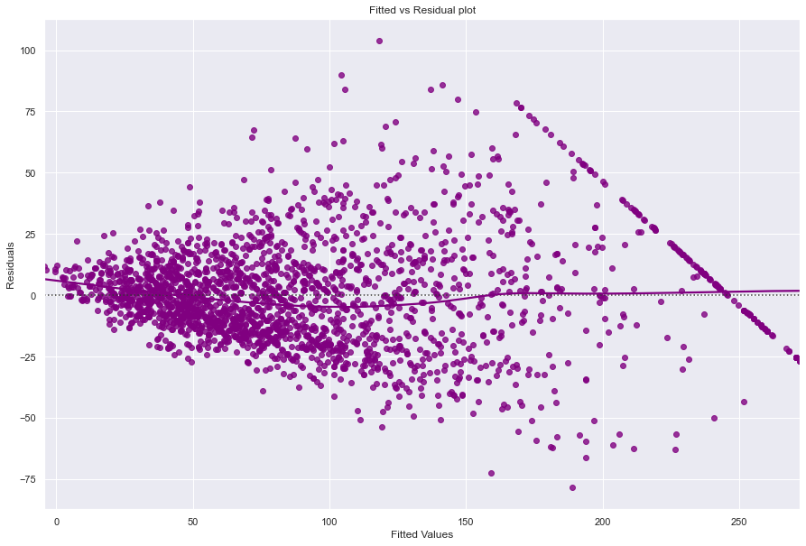

```python
# let's plot the fitted values vs residuals

sns.residplot(
    data=df_pred, x="Fitted Values", y="Residuals", color="purple", lowess=True
)
plt.xlabel("Fitted Values")
plt.ylabel("Residuals")
plt.title("Fitted vs Residual plot")
plt.show()
```

### TEST FOR NORMALITY

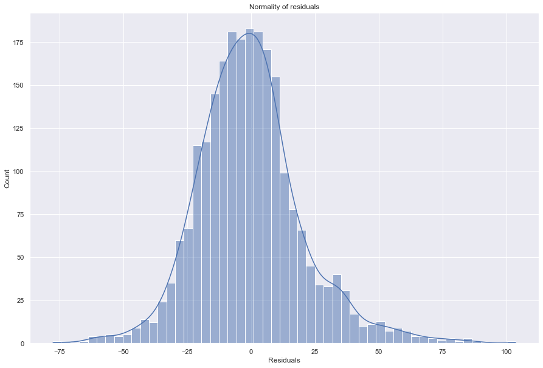

```python
sns.histplot(data=df_pred, x="Residuals", kde=True)
plt.title("Normality of residuals")
plt.show()
```

- The histogram of residuals does have a bell shape.
- Let's check the Q-Q plot.

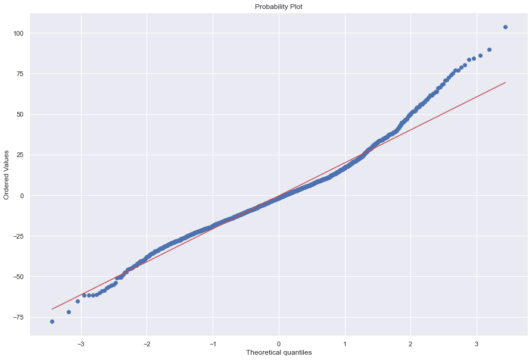

```python
import pylab
import scipy.stats as stats

stats.probplot(df_pred["Residuals"], dist="norm", plot=pylab)
plt.show()
```

- The residuals more or less follow a straight line except for the tails.
- Let's check the results of the Shapiro-Wilk test.

```python
stats.shapiro(df_pred["Residuals"])
```

```
ShapiroResult(statistic=0.9716421365737915, pvalue=3.3734527662670446e-21)
```

- Since p-value < 0.05, the residuals are not normal as per the Shapiro-Wilk test.
- Strictly speaking, the residuals are not normal.
- However, as an approximation, we can accept this distribution as close to being normal.
- **So, the assumption is satisfied.**

### TEST FOR HOMOSCEDASTICITY

```python
import statsmodels.stats.api as sms
from statsmodels.compat import lzip

name = ["F statistic", "p-value"]
test = sms.het_goldfeldquandt(df_pred["Residuals"], x_train_final)
lzip(name, test)
```

```
[('F statistic', 1.0654310933381863), ('p-value', 0.14112269394353816)]
```

**Since p-value > 0.05, we can say that the residuals are homoscedastic. So, this assumption is satisfied.**

**Now that we have checked all the assumptions of linear regression and they are satisfied, we can move towards the prediction part.**

```python
# predictions on the test set
pred = olsmod2.predict(x_test_final)

df_pred_test = pd.DataFrame({"Actual": y_test_sm, "Predicted": pred})
df_pred_test.sample(10, random_state=1)
```

|  | Actual | Predicted |
| --- | --- | --- |
| 1467 | 93.1700 | 118.618383 |
| 1041 | 74.7500 | 90.585870 |
| 3545 | 247.1925 | 190.634999 |
| 1202 | 109.8000 | 80.149991 |
| 3513 | 83.1600 | 59.411924 |
| 2447 | 247.1925 | 236.210764 |
| 1247 | 120.8400 | 111.376061 |
| 3471 | 152.8100 | 130.988516 |
| 1482 | 60.0200 | 84.506598 |
| 2651 | 150.3500 | 110.070237 |

- The model has returned good prediction results, and the actual and predicted values are comparable for most cases.
- We can also visualize comparison result as a bar graph.

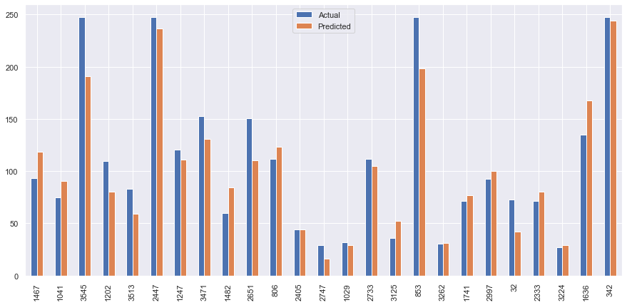

```python
df1 = df_pred_test.sample(25, random_state=1)
df1.plot(kind="bar", figsize=(15, 7))
plt.show()
```

```python
# checking model performance on train set (seen 70% data)
print("Training Performance\n")
olsmod2_train_perf = model_performance_regression(olsmod2, x_train_final, y_train_sm)
olsmod2_train_perf
```

```
Training Performance
```

|  | RMSE | MAE | R-squared | Adj. R-squared | MAPE |
| --- | --- | --- | --- | --- | --- |
| 0 | 20.595608 | 15.388272 | 0.890274 | 0.888907 | 21.080383 |

```python
# checking model performance on test set (seen 30% data)
print("Test Performance\n")
olsmod2_test_perf = model_performance_regression(olsmod2, x_test_final, y_test_sm)
olsmod2_test_perf
```

```
Test Performance
```

|  | RMSE | MAE | R-squared | Adj. R-squared | MAPE |
| --- | --- | --- | --- | --- | --- |
| 0 | 21.630428 | 16.175851 | 0.893233 | 0.890077 | 22.921057 |

- The model is able to explain ~89% of the variation in the data, which is very good.
- The train and test RMSE and MAE differences are low and comparable. So, our model is not suffering from overfitting.
- The MAPE on the test set suggests we can predict within 23% of the used_price.
- Hence, we can conclude the model *olsmod2* is good for prediction as well as inference purposes.

**Let's compare the initial model created with sklearn and the final statsmodels model.**

```python
# training performance comparison

models_train_comp_df = pd.concat(
    [linearregression_train_perf.T, olsmod2_train_perf.T],
    axis=1,
)

models_train_comp_df.columns = [
    "Linear Regression sklearn",
    "Linear Regression statsmodels",
]

print("Training performance comparison:")
models_train_comp_df
```

```
Training performance comparison:
```

|  | Linear Regression sklearn | Linear Regression statsmodels |
| --- | --- | --- |
| RMSE | 0.094446 | 20.595608 |
| MAE | 0.076640 | 15.388272 |
| R-squared | 0.983244 | 0.890274 |
| Adj. R-squared | 0.982895 | 0.888907 |
| MAPE | 1.836847 | 21.080383 |

```python
# test performance comparison

models_test_comp_df = pd.concat(
    [linearregression_test_perf.T, olsmod2_test_perf.T],
    axis=1,
)

models_test_comp_df.columns = [
    "Linear Regression sklearn",
    "Linear Regression statsmodels",
]

print("Test performance comparison:")
models_test_comp_df
```

```
Test performance comparison:
```

|  | Linear Regression sklearn | Linear Regression statsmodels |
| --- | --- | --- |
| RMSE | 0.101140 | 21.630428 |
| MAE | 0.080199 | 16.175851 |
| R-squared | 0.983241 | 0.893233 |
| Adj. R-squared | 0.982405 | 0.890077 |
| MAPE | 1.976830 | 22.921057 |

```python
olsmodel_final = sm.OLS(y_train_sm, x_train_final).fit()
print(olsmodel_final.summary())
```

```
                                 OLS Regression Results
=======================================================================================
Dep. Variable:             used_price   R-squared (uncentered):                   0.965
Model:                            OLS   Adj. R-squared (uncentered):              0.965
Method:                 Least Squares   F-statistic:                              2392.
Date:                Sat, 21 Aug 2021   Prob (F-statistic):                        0.00
Time:                        08:06:16   Log-Likelihood:                         -10475.
No. Observations:                2357   AIC:                                  2.100e+04
Df Residuals:                    2330   BIC:                                  2.116e+04
Df Model:                          27
Covariance Type:            nonrobust
====================================================================================
                       coef    std err          t      P>|t|      [0.025      0.975]
------------------------------------------------------------------------------------
selfie_camera_mp     2.1641      0.115     18.778      0.000       1.938       2.390
int_memory           0.1726      0.016     10.914      0.000       0.142       0.204
new_price            0.3550      0.004     92.070      0.000       0.347       0.363
Alcatel             -4.4582      2.194     -2.032      0.042      -8.760      -0.156
Apple               15.8116      3.740      4.228      0.000       8.478      23.145
Asus                -6.7184      2.320     -2.896      0.004     -11.268      -2.169
Celkon             -17.0325      4.706     -3.619      0.000     -26.261      -7.804
Coolpad            -19.2999      5.569     -3.466      0.001     -30.221      -8.379
Gionee             -16.4790      3.618     -4.555      0.000     -23.574      -9.384
Google              33.2397      6.343      5.240      0.000      20.801      45.678
HTC                 -9.8838      2.471     -4.001      0.000     -14.728      -5.039
Honor                6.8487      2.474      2.769      0.006       1.998      11.699
Lava               -12.2098      4.177     -2.923      0.003     -20.401      -4.019
Lenovo              -8.4179      1.891     -4.452      0.000     -12.126      -4.710
Meizu              -17.1945      3.434     -5.008      0.000     -23.928     -10.461
Micromax            -8.4525      2.520     -3.354      0.001     -13.394      -3.511
OnePlus            -50.1104     12.010     -4.173      0.000     -73.661     -26.560
Oppo               -13.8889      2.511     -5.531      0.000     -18.813      -8.965
Others              -2.4391      0.608     -4.011      0.000      -3.631      -1.247
Others              -3.0228      0.983     -3.075      0.002      -4.950      -1.095
Panasonic          -11.5015      3.579     -3.214      0.001     -18.519      -4.484
Samsung             -4.0008      1.501     -2.665      0.008      -6.944      -1.057
Sony                -8.7687      2.939     -2.984      0.003     -14.532      -3.005
Xiaomi              -7.2560      2.471     -2.936      0.003     -12.102      -2.410
ZTE                -12.3627      2.226     -5.555      0.000     -16.727      -7.998
Others              -2.4391      0.608     -4.011      0.000      -3.631      -1.247
Others              -3.0228      0.983     -3.075      0.002      -4.950      -1.095
Windows            -11.6883      3.059     -3.822      0.000     -17.686      -5.691
5G_dum              19.1064      2.981      6.408      0.000      13.260      24.953
==============================================================================
Omnibus:                      223.162   Durbin-Watson:                   1.988
Prob(Omnibus):                  0.000   Jarque-Bera (JB):              451.402
Skew:                           0.610   Prob(JB):                     9.54e-99
Kurtosis:                       4.763   Cond. No.                     1.25e+16
==============================================================================

Notes:
[1] R² is computed without centering (uncentered) since the model does not contain a constant.
[2] Standard Errors assume that the covariance matrix of the errors is correctly specified.
[3] The smallest eigenvalue is 9.94e-25. This might indicate that there are
strong multicollinearity problems or that the design matrix is singular.
```